# What is DSA?

References:

- https://www.tutorialspoint.com/python_data_structure/index.htm
- https://www.geeksforgeeks.org/python-data-structures-and-algorithms/
- https://medium.com/@devulapellisaikumar/understanding-data-structures-and-algorithms-in-python-a-beginners-guide-70d7f9c65c8b

Data Structures and Algorithms are the foundational building blocks that guide the organization, storage, and manipulation of data.

Data structures deal with how the data is organised and held in the memory, when a program processes it. It is important to note that, the data that is stored in the disk as part of persistent storages (like relational tables) are not referred as data structure here.

An Algorithm is step by step set of instruction to process the data for a specific purpose. So, an algorithm utilises various data structures in a logical way to solve a specific computing problem.

The various data structures in computer science are divided broadly into two categories:

> Linear Data Structures: These are structures where data elements are arranged sequentially.

> > Array − It is a sequential arrangement of data elements paired with the index of the data element.

> > Linked List − Each data element contains a link to another element along with the data present in it.

> > Stack − It is a data structure which follows only to specific order of operation. LIFO(last in First Out) or FILO(First in Last Out).

> > Queue − It is similar to Stack but the order of operation is only FIFO(First In First Out).

> > Matrix − It is two dimensional data structure in which the data element is referred by a pair of indices.

> Non-linear Data Structures: Here, data elements are not in a sequence, and can form hierarchical or interconnected networks.

> > Binary Tree − It is a data structure where each data element can be connected to maximum two other data elements and it starts with a root node.

> > Heap − It is a special case of Tree data structure where the data in the parent node is either strictly greater than/ equal to the child nodes or strictly less than it’s child nodes.

> > Hash Table − It is a data structure which is made of arrays associated with each other using a hash function. It retrieves values using keys rather than index from a data element.

> > Graph − It is an arrangement of vertices and nodes where some of the nodes are connected to each other through links.

The following data structures are specific to python programming and they give greater flexibility in storing different types of data and faster processing in python environment:

> List − It is similar to array with the exception that the data elements can be of *different* data types. You can have both numeric and string data in a python list.

> Tuple − Tuples are similar to lists but they are *immutable* which means the values in a tuple cannot be modified they can only be read.

> Dictionary − The dictionary contains *Key-value* pairs as its data elements.

> Sets − A set refers to a collection of *distinct* objects. It is used to group objects together and to study their properties and relationships.

## Python Arrays:

- Unlike other programming languages like C++ or Java, **Python does not have built-in support for arrays**.
- Python has several data types like lists and tuples (especially **lists**) that are often used as arrays but, **items stored in these types of sequences need not be of the same type**.

#### Creating Array in Python

- To create an array in Python, **import the array module and use its array() function**. We can create an array of three basic types namely integer, float and Unicode characters using this function.
- The array() function accepts typecode and initializer as a parameter value and returns an object of array class.

Syntax:

```
# importing
import array as array_name

# creating array
obj = array_name.array(typecode[, initializer])
```

###### Example

```python
import array as arr

# creating an array with integer type
a = arr.array('i', [1, 2, 3])
print (type(a), a)

# creating an array with char type
a = arr.array('u', 'BAT')
print (type(a), a)

# creating an array with float type
a = arr.array('d', [1.1, 2.2, 3.3])
print (type(a), a)
```

```
<class 'array.array'> array('i', [1, 2, 3])
<class 'array.array'> array('u', 'BAT')
<class 'array.array'> array('d', [1.1, 2.2, 3.3])
```

- For more details on Arrays, refer https://www.tutorialspoint.com/python/python_arrays.htm

## Python Lists:

- List is one of the built-in data types in Python.
- A Python list is a sequence of comma separated items, enclosed in square brackets [ ].
- The items in a Python list need not be of the same data type.
- List is an **ordered** collection of items. Each item in a list has a unique position index, starting from 0.
- List can contain duplicate items.

> Note: List stores references to the objects (elements) rather than storing the actual data itself.

> > Example:

> > a = [10, 20, "GfG", 40, True]

[figure not shown]

#### Creating a Lists

```python
# Using Suqare braces
a = [1, 'hello', 3.14, True]
type(a)
```

```
list
```

```python
# Using list() Constructor
# We can also create a list by passing an iterable (like a string, tuple, or another list) to list() function.

# From a tuple
b = list((1, 2, 3, 'apple', 4.5))
print(type(b))
print(b)
```

```
<class 'list'>
[1, 2, 3, 'apple', 4.5]
```

```python
# Creating list of repeating elements
# also called repetition operation

# Create a list [2, 2, 2, 2, 2]
a = [2] * 5

# Create a list [0, 0, 0, 0, 0, 0, 0]
b = [0] * 7

print(a)
print(b)
```

```
[2, 2, 2, 2, 2]
[0, 0, 0, 0, 0, 0, 0]
```

#### Accessing list elements

- Elements in a list can be accessed using *indexing*, slicing, and matrixes.
- Python indexes start at 0, so a[0] will access the first element, while negative indexing allows us to access elements from the end of the list.
- Like index -1 represents the last elements of list.

```python
a = [10, 20, 30, 40, 50]

# Access first element
print(a[0])

# Access last element
print(a[-1])

# Access all elements except 1st element
print(a[1:])

# Access all elements except last element
print(a[:-1])
```

```
10
50
[20, 30, 40, 50]
[10, 20, 30, 40]
```

```python
# Concat lists
print([1, 2, 3] + [4, 5, 6])
```

```
[1, 2, 3, 4, 5, 6]
```

```python
# membership
print(3 in [1, 2, 3])
```

```
True
```

#### Updating Elements into List

```python
a = [10, 20, 30, 40, 50]

# Change the second element
a[1] = 25

print(a)
```

```
[10, 25, 30, 40, 50]
```

#### Removing Elements from List

- remove(): Removes the first occurrence of an element.
- pop(): Removes the element at a specific index or the last element if no index is specified.
- del statement: Deletes an element at a specified index.

```python
a = [10, 20, 30, 40, 50]

# Removes the first occurrence of 30
a.remove(30)
print("After remove(30):", a)

# Removes the element at index 1 (20)
popped_val = a.pop(1)
print("Popped element:", popped_val)
print("After pop(1):", a)

# Deletes the first element (10)
del a[0]
print("After del a[0]:", a)
```

```
After remove(30): [10, 20, 40, 50]
Popped element: 20
After pop(1): [10, 40, 50]
After del a[0]: [40, 50]
```

#### Python list methods

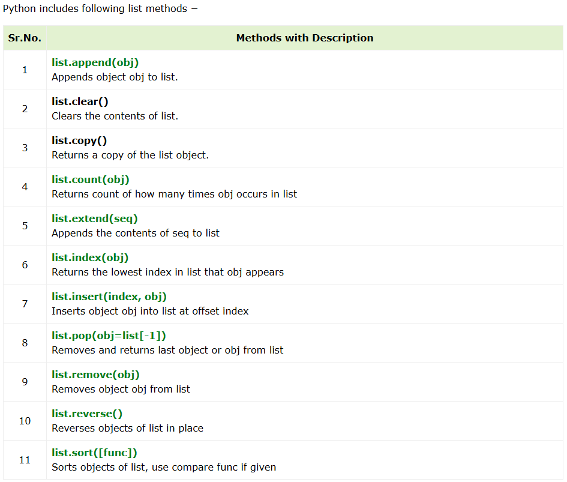

#### Built-in Functions with Lists

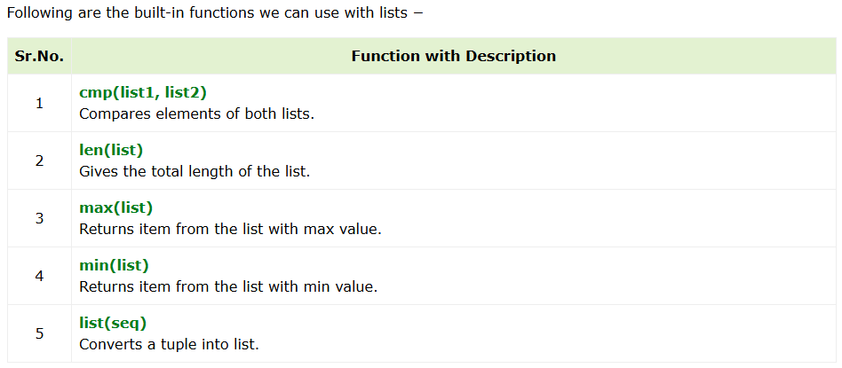

#### Iterating over list

```python
# Using FOR loop

a = [1, 3, 5, 7, 9]

# On each iteration val
# represents the current item/element
for val in a:
    print(val)
```

```
1
3
5
7
9
```

```python
# Using for Loop with range()

a = [1, 3, 5, 7, 9]

# Calculate the length of the list
n = len(a)

# Iterates over the indices from 0 to n-1 (i.e., 0 to 4)
for i in range(n):
    print(a[i])
```

```
1
3
5
7
9
```

```python
# Using while Loop

a = [1, 3, 5, 7, 9]

# Start from the first index
i = 0

# The loop runs till the last index (i.e., 4)
while i < len(a):
    print(a[i])
    i += 1
```

```
1
3
5
7
9
```

```python
# Using enumerate()

a = [1, 3, 5, 7, 9]

# Here, i and val reprsents index and value respectively
for i, val in enumerate(a):
    print (i, val)
```

```
0 1
1 3
2 5
3 7
4 9
```

```python
# Using List Comprehension

a = [1, 3, 5, 7, 9]

# On each iteration val is passed to print function
# And printed in the console.
res = [val*2 for val in a]

print(res)
```

```
[2, 6, 10, 14, 18]
```

#### Multidimensional list

- Refer https://www.geeksforgeeks.org/multi-dimensional-lists-in-python/

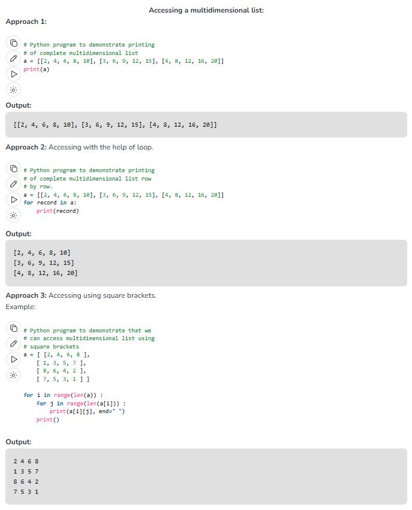

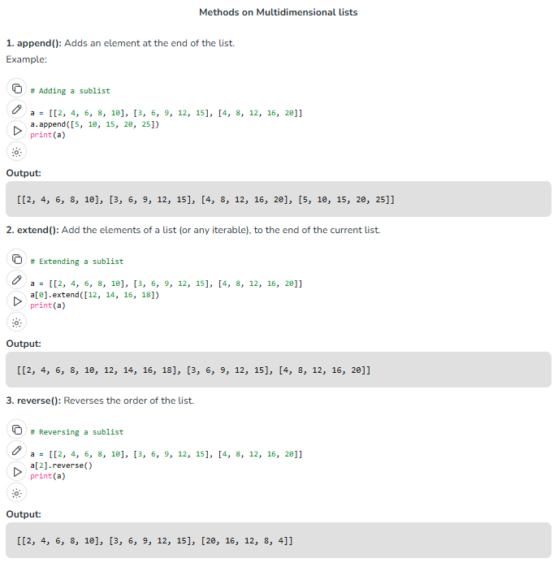

## Python Tuples:

- A Python tuple is a sequence of comma separated items, enclosed in parentheses ().
- The items in a Python tuple need not be of same data type.
- Python tuple and list both are sequences.
  - One major difference between the two is, Python **list is mutable**, whereas **tuple is immutable**. Although any item from the tuple can be accessed using its index, and cannot be modified, removed or added.

#### Creating a Tuple

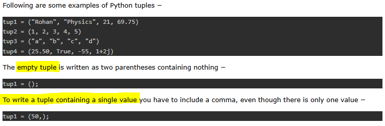

#### Update and delete tuple elements:

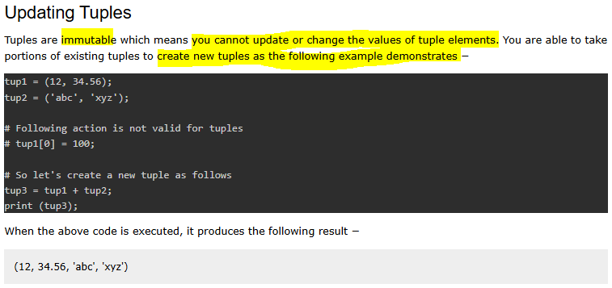

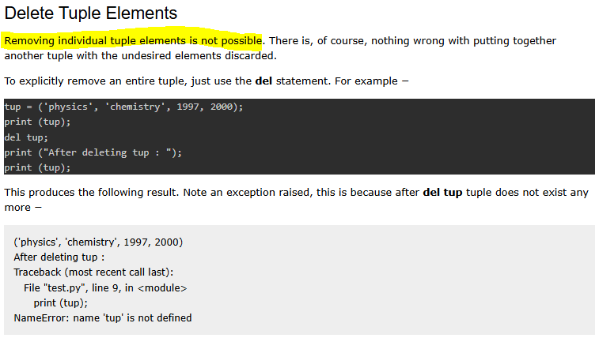

## Python Sets:

- Set is an **unordered** collection of unique elements.
- Unlike lists or tuples, sets do not allow duplicate values i.e. each element in a set must be unique.
- Sets are mutable, meaning you can add or remove items after a set has been created.
- Sets are defined using **curly braces {}** or the built-in **set()** function.
- They are particularly useful for membership testing, removing duplicates from a sequence, and performing common mathematical set operations like union, intersection, and difference.

#### Creating a set in Python

```python
# Using Curly Braces
my_set_1 = {1, 2, 3, 4, 5}
print (my_set_1)

# Using the set() Function
my_set_2 = set([10, 20, 30, 40, 50])
print (my_set_2)
```

```
{1, 2, 3, 4, 5}
{40, 10, 50, 20, 30}
```

#### Duplicate Elements in Set

```python
# Sets in Python are unordered collections of unique elements.
# If you try to create a set with duplicate elements, duplicates will be automatically removed.

my_set = {1, 2, 2, 3, 3, 4, 5, 5}
print (my_set)
```

```
{1, 2, 3, 4, 5}
```

#### Mixed set

```python
mixed_set = {1, 'hello', (1, 2, 2,3)}
print (mixed_set)

# Note: an elements inside a set (eg: tuple) can still have duplicates
```

```
{1, 'hello', (1, 2, 2, 3)}
```

```python
# Note: mutable types like list cannot be added as set element
mixed_set = {1, 'hello', [1, 2, 3]}
print (mixed_set)
```

```
---------------------------------------------------------------------------
TypeError                                 Traceback (most recent call last)
Cell In[30], line 2
      1 # Note: mutable types like list cannot be added as set element
----> 2 mixed_set = {1, 'hello', [1, 2, 3]}
      3 print (mixed_set)

TypeError: unhashable type: 'list'
```

#### Adding and removing elements in Set:

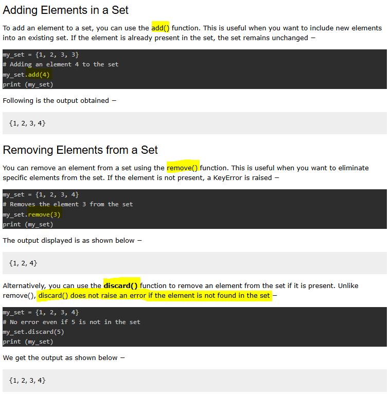

#### Set Operations:

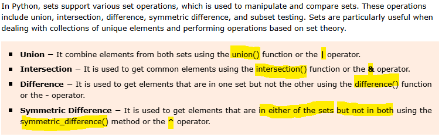

#### Set comprehensions:

```python
# You can include conditional statements in set comprehensions to filter elements based on certain criteria
even_set = {x for x in range(1, 11) if x % 2 == 0}
print(even_set)
```

```
{2, 4, 6, 8, 10}
```

#### Frozen Sets

- a frozen set is an **immutable collection** of **unique elements**, similar to a regular set but with the distinction that **it cannot be modified after creation**.
- Once created, the elements within a frozen set cannot be added, removed, or modified, making it a suitable choice when you need an immutable set.
- You can create a frozen set in Python using the **frozenset()** function by passing an iterable (such as a list, tuple, or another set) containing the elements you want to include in the frozen set.

```python
my_frozen_set = frozenset([1, 2, 3])
print(my_frozen_set)
print("\n********************************\n")
# we cannot add element to frozen set.. ERROR!!
my_frozen_set.add(4)
```

```
frozenset({1, 2, 3})
```

```
---------------------------------------------------------------------------
AttributeError                            Traceback (most recent call last)
Cell In[32], line 5
      3 print("\n********************************\n")
      4 # we cannot add element to frozen set.. ERROR!!
----> 5 my_frozen_set.add(4)

AttributeError: 'frozenset' object has no attribute 'add'
```

## Python Dictionary

- a dictionary is a built-in data type that stores data in key-value pairs.
- It is an unordered (after Python 3.7, dictionaries are ordered), mutable, and indexed collection.
- Each key in a dictionary is unique and maps to a value.
- Dictionaries are often used to store data that is related, such as information associated with a specific entity or object, where you can quickly retrieve a value based on its key.

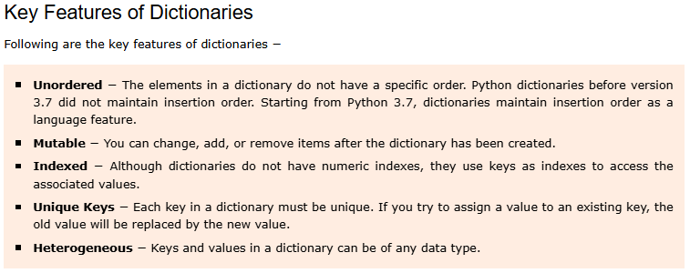

#### Creating a dictionary:

```python
d = {10 : "hello", 20 : "geek", "hello" : "world", 2.0 : 55}
print(d)
```

```
{10: 'hello', 20: 'geek', 'hello': 'world', 2.0: 55}
```

```python
# Note:
# Only a number, string or tuple can be used as key. All of them are immutable.
# object of any type can be the value

d1 = {"Fruit":["Mango","Banana"], "Flower":["Rose", "Lotus"]}
d2 = {('India, USA'):'Countries', ('New Delhi', 'New York'):'Capitals'}
print (d1)
print (d2)

print("\n**************************************************************\n")

# can't use mutable objects such as list as key, and raises TypeError.
d3 = {["Mango","Banana"]:"Fruit", "Flower":["Rose", "Lotus"]}
print (d3)
```

```
{'Fruit': ['Mango', 'Banana'], 'Flower': ['Rose', 'Lotus']}
{'India, USA': 'Countries', ('New Delhi', 'New York'): 'Capitals'}
```

```
---------------------------------------------------------------------------
TypeError                                 Traceback (most recent call last)
Cell In[34], line 13
     10 print("\n**************************************************************\n")
     12 # can't use mutable objects such as list as key, and raises TypeError.
---> 13 d3 = {["Mango","Banana"]:"Fruit", "Flower":["Rose", "Lotus"]}
     14 print (d3)

TypeError: unhashable type: 'list'
```

```python
# You can assign a value to more than one keys in a dictionary, but a key cannot appear more than once in a dictionary.
d1 = {"Banana":"Fruit", "Rose":"Flower", "Lotus":"Flower", "Mango":"Fruit"}
d2 = {"Fruit":"Banana","Flower":"Rose", "Fruit":"Mango", "Flower":"Lotus"}
print (d1)
print (d2)
```

```
{'Banana': 'Fruit', 'Rose': 'Flower', 'Lotus': 'Flower', 'Mango': 'Fruit'}
{'Fruit': 'Mango', 'Flower': 'Lotus'}
```

#### Accessing Dictionary Items

- You can access the value associated with a specific key using **square brackets []** or the **get()** method

```python
student_info = {
   "name": "Alice",
   "age": 21,
   "major": "Computer Science"
}
# Accessing values using square brackets
name = student_info["name"]
print("Name:",name)

# Accessing values using the get() method
age = student_info.get("age")
print("Age:",age)
```

```
Name: Alice
Age: 21
```

#### Modifying / Add Dictionary Items

- You can modify the value associated with a specific key or add a new key-value pair

```python
student_info = {
   "name": "Alice",
   "age": 21,
   "major": "Computer Science"
}
# Modifying an existing key-value pair
student_info["age"] = 22

# Adding a new key-value pair
student_info["graduation_year"] = 2023
print("The modified dictionary is:",student_info)
```

```
The modified dictionary is: {'name': 'Alice', 'age': 22, 'major': 'Computer Science', 'graduation_year': 2023}
```

#### Removing Dictionary Items

- You can remove items using the **del statement**, the **pop()** method, or the **popitem()** method

```python
student_info = {
   "name": "Alice",
   "age": 22,
   "major": "Computer Science",
   "graduation_year": 2023
}
# Removing an item using the del statement
del student_info["major"]

# Removing an item using the pop() method
graduation_year = student_info.pop("graduation_year")

print(student_info)
```

```
{'name': 'Alice', 'age': 22}
```

#### Iterating Through a Dictionary

```python
student_info = {
   "name": "Alice",
   "age": 22,
   "major": "Computer Science",
   "graduation_year": 2023
}
# Iterating through keys
for key in student_info:
   print("Keys:",key, student_info[key])

# Iterating through values
for value in student_info.values():
   print("Values:",value)

# Iterating through key-value pairs
for key, value in student_info.items():
   print("Key:Value:",key, value)
```

```
Keys: name Alice
Keys: age 22
Keys: major Computer Science
Keys: graduation_year 2023
Values: Alice
Values: 22
Values: Computer Science
Values: 2023
Key:Value: name Alice
Key:Value: age 22
Key:Value: major Computer Science
Key:Value: graduation_year 2023
```

#### Python Dictionary Operators

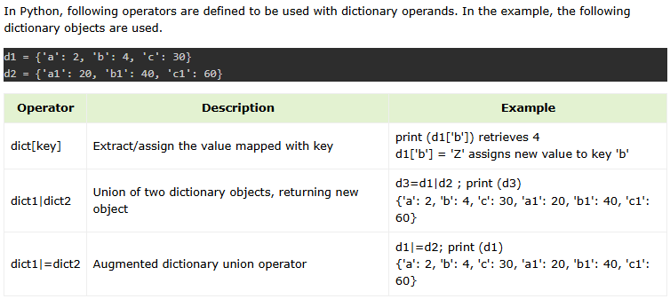

#### Python Dictionary Methods

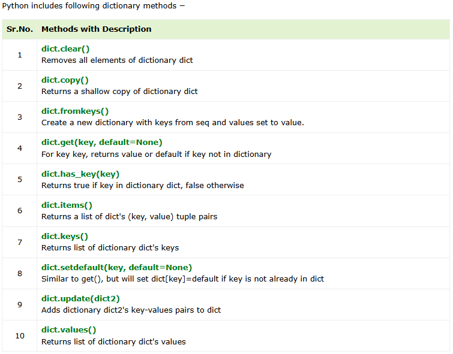

#### Built-in Functions with Dictionaries

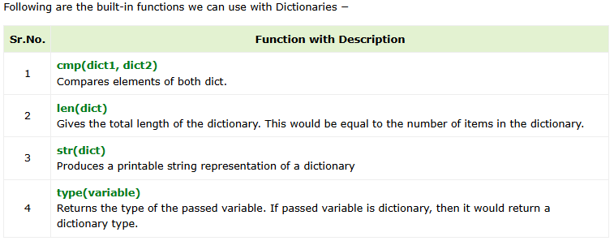

## Linked List

- A linked list is a sequence of data elements, which are connected together via links.
- Each data element contains a connection to another data element in form of a pointer.
- Python **does not have linked lists in its standard library**. We implement the concept of linked lists using the concept of **nodes**.